# Larval stages respirometry (photosynthesis & respiration) analysis and plotting

AS Huffmyer

2021

This script analyzes and plots data for respirometry data across *Pocillopora acuta* larval stages (I, II, III).

# **Setup**

Set up workspace, set options, and load required packages.

```r
knitr::opts_chunk$set(echo = TRUE, warning = FALSE, message = FALSE)
```

```r
## install packages if you dont already have them in your library
if ("tidyverse" %in% rownames(installed.packages()) == 'FALSE') install.packages('tidyverse')
if ("car" %in% rownames(installed.packages()) == 'FALSE') install.packages('car')
if ("lme4" %in% rownames(installed.packages()) == 'FALSE') install.packages('lme4')
if ("lmerTest" %in% rownames(installed.packages()) == 'FALSE') install.packages('lmerTest')
if ("scales" %in% rownames(installed.packages()) == 'FALSE') install.packages('scales')
if ("cowplot" %in% rownames(installed.packages()) == 'FALSE') install.packages('cowplot')
if ("ggplot2" %in% rownames(installed.packages()) == 'FALSE') install.packages('ggplot2')
if ("effects" %in% rownames(installed.packages()) == 'FALSE') install.packages('effects')
if ("emmeans" %in% rownames(installed.packages()) == 'FALSE') install.packages('emmeans')
if ("multcomp" %in% rownames(installed.packages()) == 'FALSE') install.packages('multcomp')

#load packages
library("ggplot2")
library("tidyverse")
library('car')
library('lme4')
library('lmerTest')
library('scales')
library('cowplot')
library('effects')
library('emmeans')
library('multcomp')
```

# **Data visualization**

Load data generated from LoLinR rates extraction.

```r
PRdata<-read.csv("Pacu2021/Output/Respiration/Stages/oxygen_P_R_calc.csv") #load data
```

Format data columns and remove blank wells.

```r
#remove all rows of wells that did not have samples or blanks
PRdata<-PRdata[!is.na(PRdata$Type),]

#format columns
PRdata$Temperature<-as.factor(PRdata$Temperature)
PRdata$Stage<-as.factor(PRdata$Stage)
PRdata$Treatment<-as.factor(PRdata$Treatment)
PRdata$Plate<-as.factor(PRdata$Plate)
PRdata$Run<-as.factor(PRdata$Run)
```

Calculate a P:R ratio = gross photosynthesis / respiration. A 1:1 ratio indicates that photosynthesis meets respiratory demand.

```r
PRdata$ratio<-abs(PRdata$GP.nmol.org.min)/abs(PRdata$R.nmol.org.min) #calculate ratio with absolute values
#remove outliers detected by values of P:R ratio data
```

View boxplots for each metric. For P:R ratio, remove outliers >15.

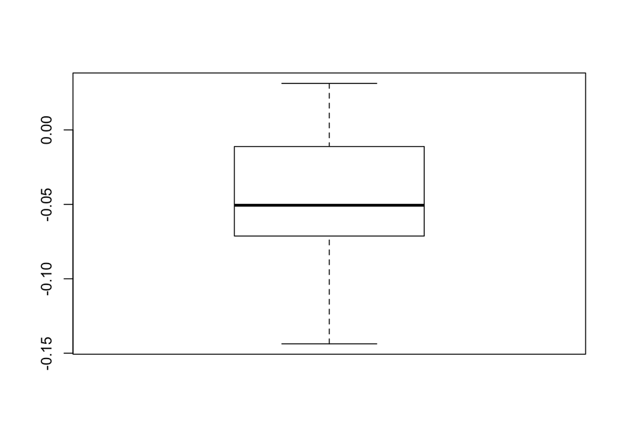

```r
boxplot(PRdata$R.nmol.org.min)
```

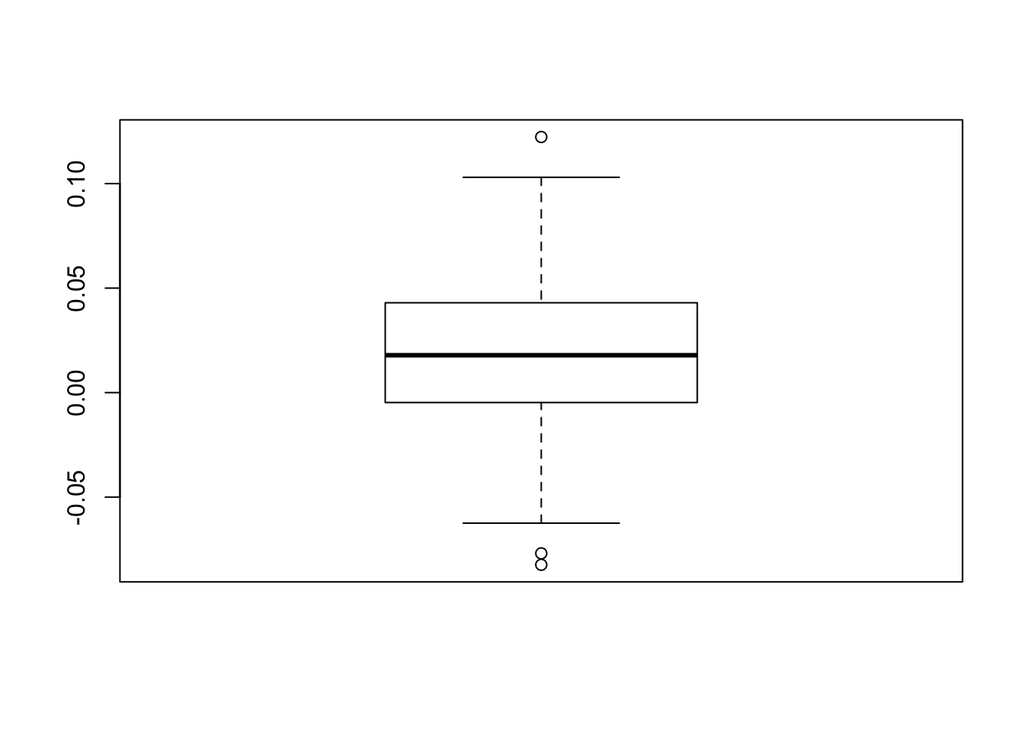

```r
boxplot(PRdata$P.nmol.org.min)
```

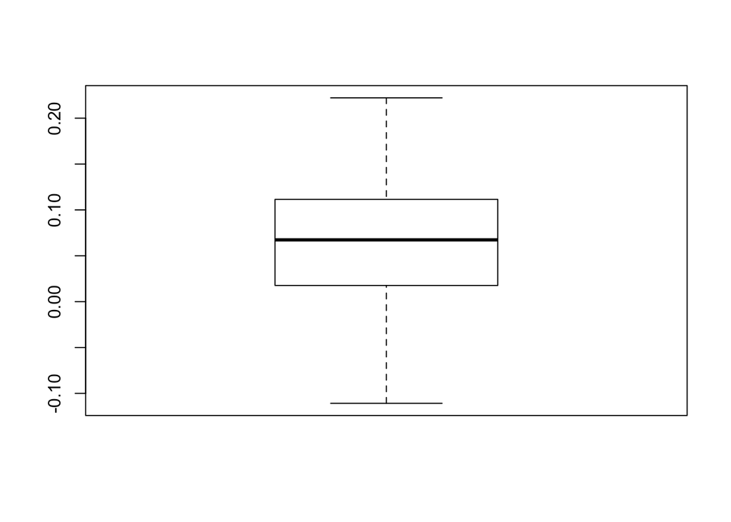

```r
boxplot(PRdata$GP.nmol.org.min)
```

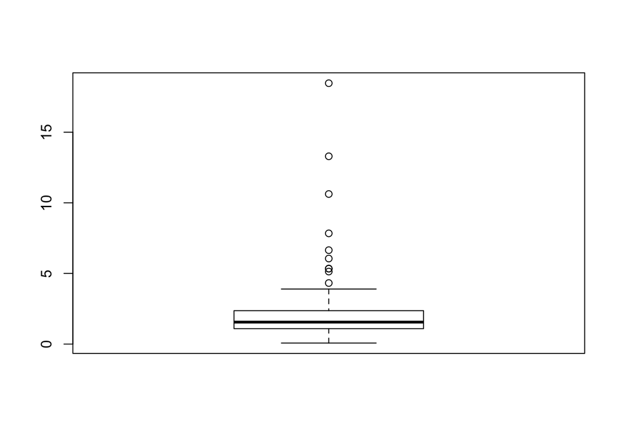

```r
boxplot(PRdata$ratio)
```

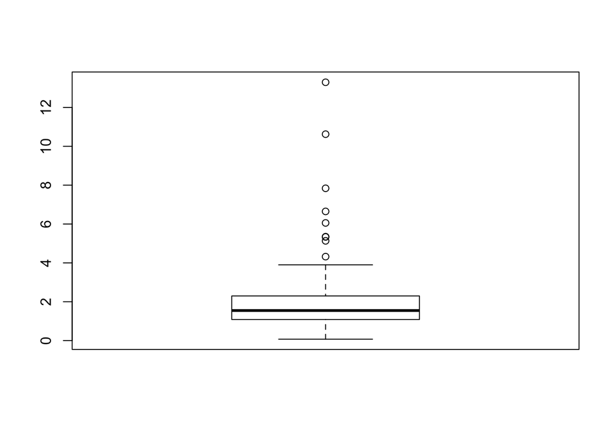

```r
PRdata<-PRdata%>%filter(ratio < 15) #filter out outlier for PR ratio
boxplot(PRdata$ratio)
```

# **Plotting**

In these plots, there are several factors displayed:  
1) “Treatment” = larval rearing treatment, either high or ambient  
2) “Temperature” = temperature at which respirometry was conducted, either 27C or 31C  
3) “Stage” = the larval stage, either 1 (planula), 2 (metamorphosing), or 3 (polyp)

## Respiration

Respiration data provides information on organism energetic demand. Here, respiration is shown as the absolute value of oxygen consumed per larva per unit time.

First, plot data as a box plot.

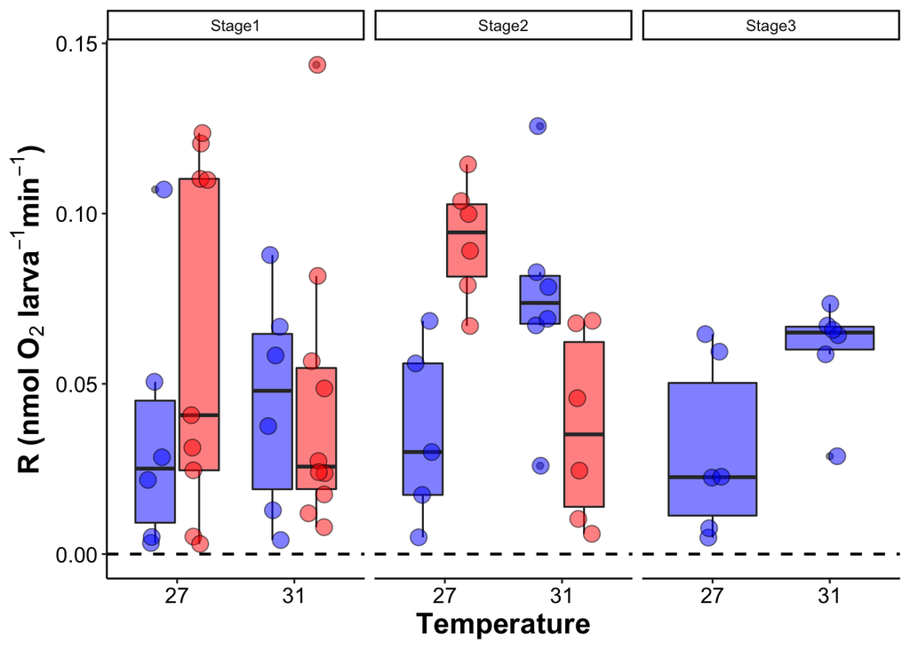

```r
r_plot<-PRdata %>%
    droplevels()%>%
    group_by(Temperature)%>%
    mutate(abs=abs(R.nmol.org.min))%>%
    ggplot(., aes(x = as.factor(Temperature), y = abs, group=interaction(Treatment, Temperature))) +
    facet_wrap(~Stage)+
    geom_hline(yintercept=0, linetype="dashed", color="black", size=0.75)+
    geom_boxplot(aes(fill=Treatment, group=interaction(Treatment,Temperature)), alpha=0.5)+
    geom_point(aes(fill=Treatment, group=interaction(Treatment, Temperature)), pch = 21, size=4, alpha=0.5, position = position_jitterdodge(0.3)) +
    xlab("Temperature") +
    scale_fill_manual(name="Temperature", values=c("blue","red"))+
    scale_color_manual(name="Temperature", values=c("blue","red"))+
    ylab(expression(bold(paste("R (nmol ", O[2], " larva"^-1, "min"^-1, ")")))) +
    #scale_y_continuous(limits=c(-0.2, 0.06), labels = scales::number_format(accuracy = 0.01, decimal.mark = '.'))+
    theme_classic() +
    theme(
      legend.position="none",
      axis.title=element_text(face="bold", size=16),
      axis.text=element_text(size=12, color="black"),
      legend.title=element_text(face="bold", size=14),
      legend.text=element_text(size=12)
      ); r_plot
```

Next plot as an interaction plot.

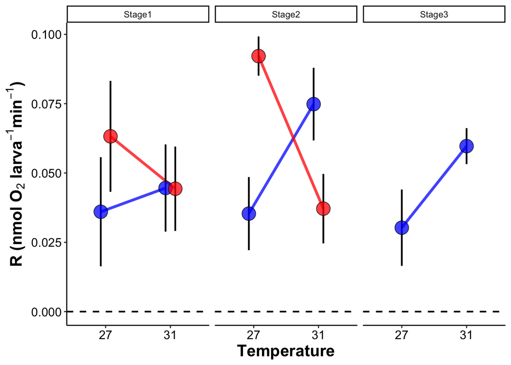

```r
r_plot_b<-PRdata %>%
    group_by(Temperature, Treatment, Stage)%>%
    mutate(abs=abs(R.nmol.org.min))%>%
    summarise(mean=mean(abs), sd=sd(R.nmol.org.min), N=length(R.nmol.org.min), se=sd/sqrt(N))%>%
    ggplot(., aes(x = as.factor(Temperature), y = mean, group=Treatment)) +
    facet_wrap(~Stage)+
    geom_hline(yintercept=0, linetype="dashed", color="black", size=0.75)+
    geom_line(position=position_dodge(0.3), size=1.3, alpha=0.75,aes(color=Treatment, group=Treatment)) +
    geom_errorbar(aes(ymin=mean-se, ymax=mean+se, group=Treatment), width=0, linetype="solid", position=position_dodge(0.3), size=0.8, color="black")+
     geom_point(aes(fill=Treatment, group=Treatment), pch = 21, size=6, alpha=0.75, position = position_dodge(0.3)) +
    xlab("Temperature") +
    scale_fill_manual(name="Treatment", values=c("blue","red"))+
    scale_color_manual(name="Treatment", values=c("blue","red"))+
    ylab(expression(bold(paste("R (nmol ", O[2], " larva"^-1, "min"^-1, ")")))) +
    #scale_y_continuous(limits=c(-0.2, 0.06), labels = scales::number_format(accuracy = 0.01, decimal.mark = '.'))+
    theme_classic() +
    theme(
      legend.position="none",
      axis.title=element_text(face="bold", size=16),
      axis.text=element_text(size=12, color="black"),
      legend.title=element_text(face="bold", size=14),
      legend.text=element_text(size=12)
      ); r_plot_b
```

## Photosynthesis (Net)

Net photosynthesis shows the oxygen production that occurs in excess of oxygen consumption (respiration).

Plot data as a box plot.

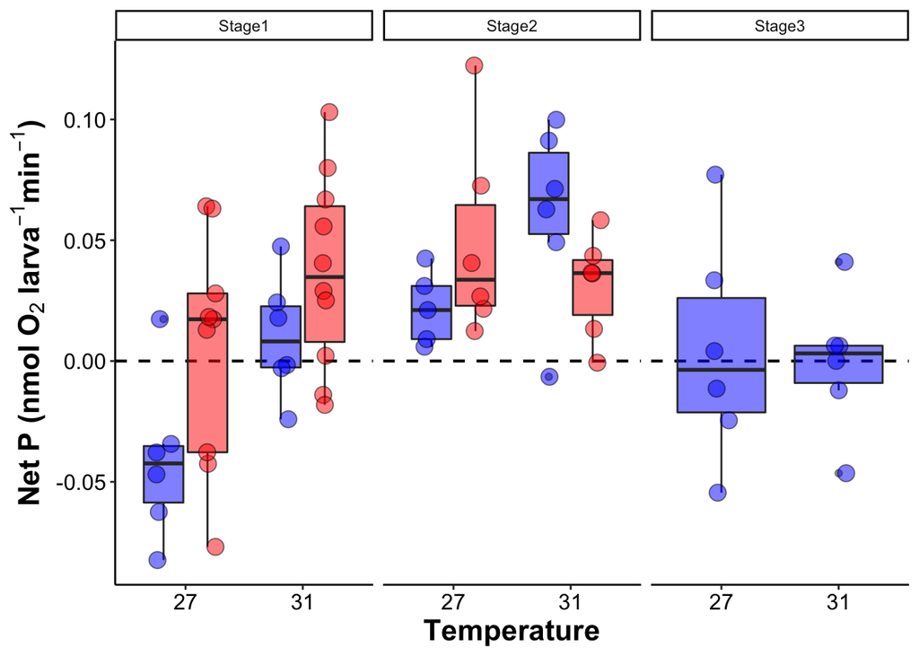

```r
p_plot<-PRdata %>%
    droplevels()%>%
    group_by(Temperature)%>%
    ggplot(., aes(x = as.factor(Temperature), y = P.nmol.org.min, group=Temperature)) +
    facet_wrap(~Stage)+
    geom_hline(yintercept=0, linetype="dashed", color="black", size=0.75)+
    geom_boxplot(aes(fill=Treatment, group=interaction(Treatment,Temperature)), alpha=0.5)+
    geom_point(aes(fill=Treatment, group=interaction(Treatment,Temperature)), pch = 21, size=4, alpha=0.5, position = position_jitterdodge(0.3)) +
    xlab("Temperature") +
    scale_fill_manual(name="Temperature", values=c("blue", "red"))+
    scale_color_manual(name="Temperature", values=c("blue", "red"))+
    ylab(expression(bold(paste("Net P (nmol ", O[2], " larva"^-1, "min"^-1, ")")))) +
    #scale_y_continuous(limits=c(-0.005, 0.03), labels = scales::number_format(accuracy = 0.01, decimal.mark = '.'))+
    theme_classic() +
    theme(
      legend.position="none",
      axis.title=element_text(face="bold", size=16),
      axis.text=element_text(size=12, color="black"),
      legend.title=element_text(face="bold", size=14),
      legend.text=element_text(size=12)
      ); p_plot
```

Plot as an interaction plot.

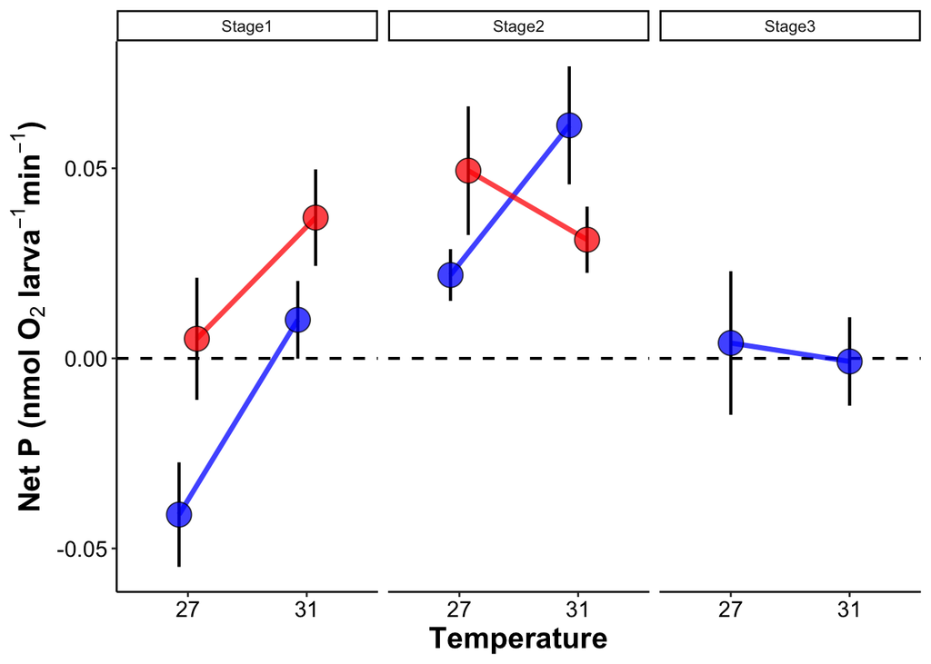

```r
p_plot_b<-PRdata %>%
    group_by(Temperature, Treatment, Stage)%>%
    summarise(mean=mean(P.nmol.org.min), sd=sd(P.nmol.org.min), N=length(P.nmol.org.min), se=sd/sqrt(N))%>%
    ggplot(., aes(x = as.factor(Temperature), y = mean, group=Treatment)) +
    facet_wrap(~Stage)+
    geom_hline(yintercept=0, linetype="dashed", color="black", size=0.75)+
    geom_line(position=position_dodge(0.3), size=1.3, alpha=0.75,aes(color=Treatment, group=Treatment)) +
    geom_errorbar(aes(ymin=mean-se, ymax=mean+se, group=Treatment), width=0, linetype="solid", position=position_dodge(0.3), size=0.8, color="black")+
     geom_point(aes(fill=Treatment, group=Treatment), pch = 21, size=6, alpha=0.75, position = position_dodge(0.3)) +
    xlab("Temperature") +
    scale_fill_manual(name="Treatment", values=c("blue","red"))+
    scale_color_manual(name="Treatment", values=c("blue","red"))+
    ylab(expression(bold(paste("Net P (nmol ", O[2], " larva"^-1, "min"^-1, ")")))) +
    #scale_y_continuous(limits=c(-0.2, 0.06), labels = scales::number_format(accuracy = 0.01, decimal.mark = '.'))+
    theme_classic() +
    theme(
      legend.position="none",
      axis.title=element_text(face="bold", size=16),
      axis.text=element_text(size=12, color="black"),
      legend.title=element_text(face="bold", size=14),
      legend.text=element_text(size=12)
      ); p_plot_b
```

## Photosynthesis (Gross)

Gross photosynthesis is calculated by removing oxygen consumption (respiration) therefore showing total oxygen production (photosynthesis).

First, lot data as a box plot.

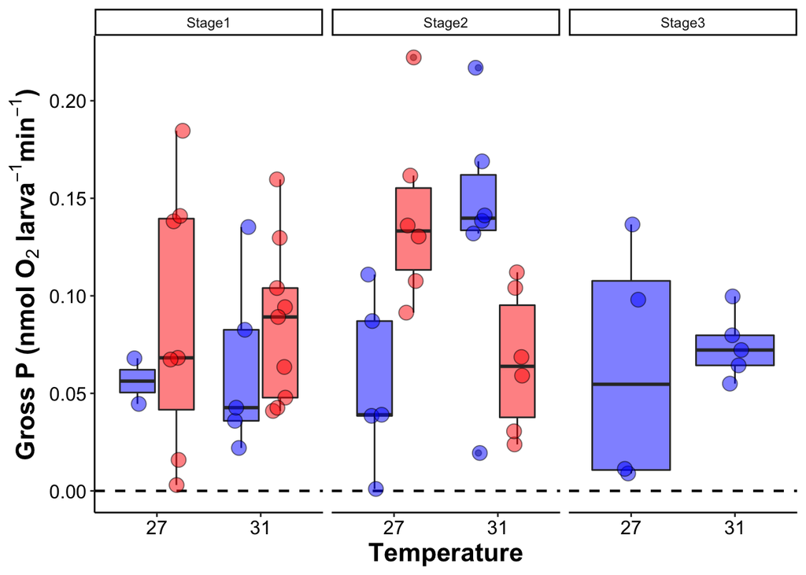

```r
gp_plot<-PRdata %>%
    group_by(Temperature)%>%
    filter(GP.nmol.org.min>0)%>%
    ggplot(., aes(x = as.factor(Temperature), y = GP.nmol.org.min, group=Temperature)) +
    facet_wrap(~Stage)+
    geom_hline(yintercept=0, linetype="dashed", color="black", size=0.75)+
    geom_boxplot(aes(fill=Treatment, group=interaction(Treatment,Temperature)), alpha=0.5)+
    geom_point(aes(fill=Treatment, group=interaction(Treatment,Temperature)), pch = 21, size=4, alpha=0.5, position = position_jitterdodge(0.3)) +
    xlab("Temperature") +
    scale_fill_manual(name="Temperature", values=c("blue", "red"))+
    scale_color_manual(name="Temperature", values=c("blue", "red"))+
    ylab(expression(bold(paste("Gross P (nmol ", O[2], " larva"^-1, "min"^-1, ")")))) +
    #scale_y_continuous(limits=c(-0.005, 0.05), labels = scales::number_format(accuracy = 0.01, decimal.mark = '.'))+
    theme_classic() +
    theme(
      legend.position="none",
      axis.title=element_text(face="bold", size=16),
      axis.text=element_text(size=12, color="black"),
      legend.title=element_text(face="bold", size=14),
      legend.text=element_text(size=12)
      ); gp_plot
```

Next plot as an interaction plot.

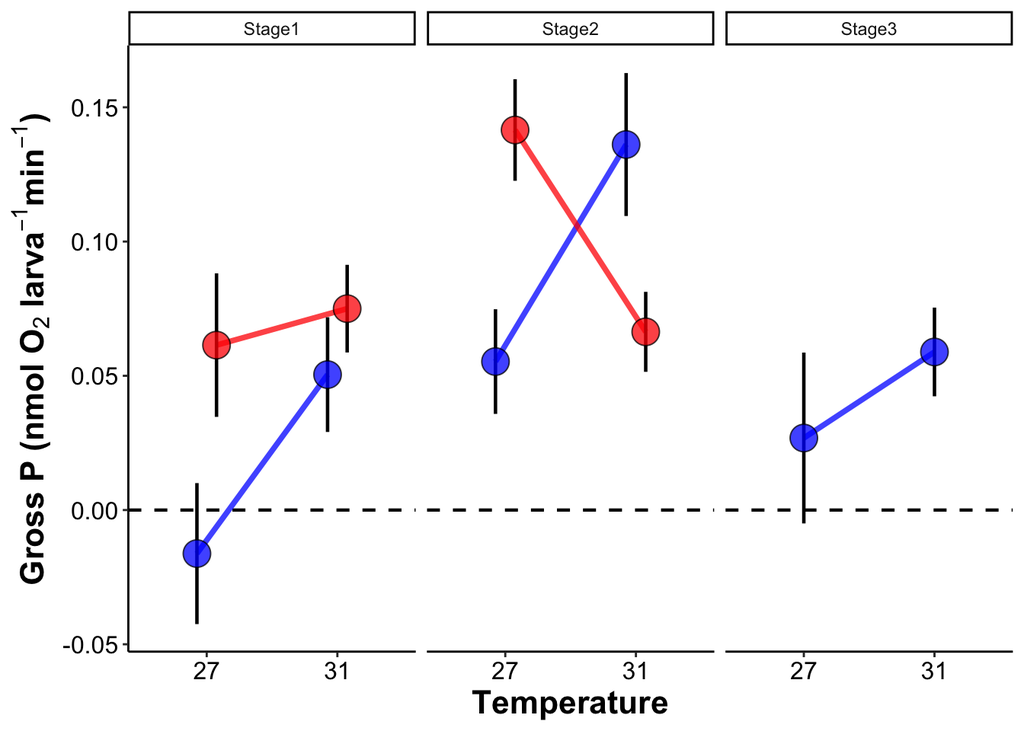

```r
gp_plot_b<-PRdata %>%
    group_by(Temperature, Treatment, Stage)%>%
    summarise(mean=mean(GP.nmol.org.min), sd=sd(GP.nmol.org.min), N=length(GP.nmol.org.min), se=sd/sqrt(N))%>%
    ggplot(., aes(x = as.factor(Temperature), y = mean, group=Treatment)) +
    facet_wrap(~Stage)+
    geom_hline(yintercept=0, linetype="dashed", color="black", size=0.75)+
    geom_line(position=position_dodge(0.3), size=1.3, alpha=0.75,aes(color=Treatment, group=Treatment)) +
    geom_errorbar(aes(ymin=mean-se, ymax=mean+se, group=Treatment), width=0, linetype="solid", position=position_dodge(0.3), size=0.8, color="black")+
     geom_point(aes(fill=Treatment, group=Treatment), pch = 21, size=6, alpha=0.75, position = position_dodge(0.3)) +
    xlab("Temperature") +
    scale_fill_manual(name="Treatment", values=c("blue","red"))+
    scale_color_manual(name="Treatment", values=c("blue","red"))+
    ylab(expression(bold(paste("Gross P (nmol ", O[2], " larva"^-1, "min"^-1, ")")))) +
    #scale_y_continuous(limits=c(-0.2, 0.06), labels = scales::number_format(accuracy = 0.01, decimal.mark = '.'))+
    theme_classic() +
    theme(
      legend.position="none",
      axis.title=element_text(face="bold", size=16),
      axis.text=element_text(size=12, color="black"),
      legend.title=element_text(face="bold", size=14),
      legend.text=element_text(size=12)
      ); gp_plot_b
```

## P:R Ratio

P:R ratio shows the energy balance between photosynthesis and respiration. A ratio of 1 indicates that gross photosynthesis = respiration. Values >1 indicate more oxygen is produced than consumed.

Plot data as a box plot.

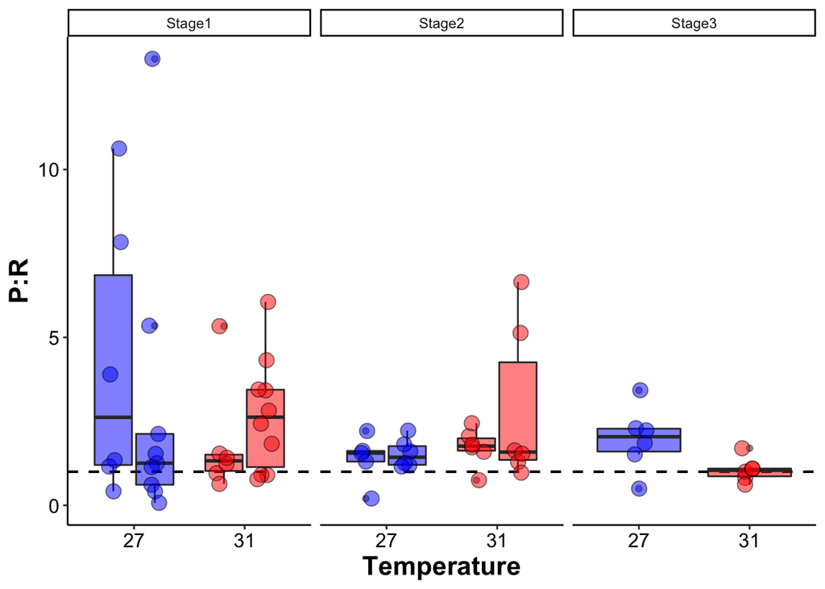

```r
pr_plot<-PRdata %>%
    group_by(Temperature)%>%
    ggplot(., aes(x = as.factor(Temperature), y = ratio, group=Temperature)) +
    facet_wrap(~Stage)+
    geom_hline(yintercept=1, linetype="dashed", color="black", size=0.75)+
    geom_boxplot(aes(fill=Temperature, group=interaction(Treatment,Temperature)), alpha=0.5)+
    geom_point(aes(fill=Temperature, group=interaction(Treatment,Temperature)), pch = 21, size=4, alpha=0.5, position = position_jitterdodge(0.3)) +
    xlab("Temperature") +
    scale_fill_manual(name="Temperature", values=c("blue", "red"))+
    scale_color_manual(name="Temperature", values=c("blue", "red"))+
    ylab(expression(bold(paste("P:R")))) +
    #scale_y_continuous(limits=c(0.8, 3), labels = scales::number_format(accuracy = 0.01, decimal.mark = '.'))+
    theme_classic() +
    theme(
      legend.position="none",
      axis.title=element_text(face="bold", size=16),
      axis.text=element_text(size=12, color="black"),
      legend.title=element_text(face="bold", size=14),
      legend.text=element_text(size=12)
      ); pr_plot
```

Plot as an interaction plot.

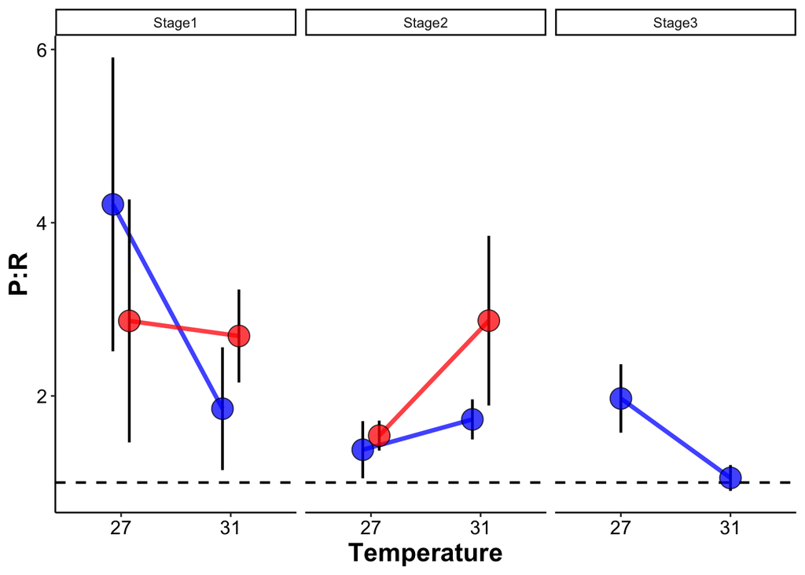

```r
pr_plot_b<-PRdata %>%
    group_by(Temperature, Treatment, Stage)%>%
    summarise(mean=mean(ratio), sd=sd(ratio), N=length(ratio), se=sd/sqrt(N))%>%
    ggplot(., aes(x = as.factor(Temperature), y = mean, group=Treatment)) +
    facet_wrap(~Stage)+
    geom_hline(yintercept=1, linetype="dashed", color="black", size=0.75)+
    geom_line(position=position_dodge(0.3), size=1.3, alpha=0.75,aes(color=Treatment, group=Treatment)) +
    geom_errorbar(aes(ymin=mean-se, ymax=mean+se, group=Treatment), width=0, linetype="solid", position=position_dodge(0.3), size=0.8, color="black")+
     geom_point(aes(fill=Treatment, group=Treatment), pch = 21, size=6, alpha=0.75, position = position_dodge(0.3)) +
    xlab("Temperature") +
    scale_fill_manual(name="Treatment", values=c("blue","red"))+
    scale_color_manual(name="Treatment", values=c("blue","red"))+
    ylab(expression(bold(paste("P:R")))) +
    #scale_y_continuous(limits=c(-0.2, 0.06), labels = scales::number_format(accuracy = 0.01, decimal.mark = '.'))+
    theme_classic() +
    theme(
      legend.position="none",
      axis.title=element_text(face="bold", size=16),
      axis.text=element_text(size=12, color="black"),
      legend.title=element_text(face="bold", size=14),
      legend.text=element_text(size=12)
      ); pr_plot_b
```

## Generate final figure of all plots together.

Box plot figures:

```r
full_fig<-plot_grid(r_plot, p_plot, gp_plot, pr_plot, ncol=4, nrow=1, rel_heights= c(1,1,1,1), rel_widths = c(1,1,1,1), label_y=1, align="h")

ggsave(filename="Pacu2021/Figures/Respiration/Stages/stages_boxplots.png", plot=full_fig, dpi=500, width=18, height=6, units="in")
```

Interaction plot figures:

```r
full_fig_b<-plot_grid(r_plot_b, p_plot_b, gp_plot_b, pr_plot_b, ncol=4, nrow=1, rel_heights= c(1,1,1,1), rel_widths = c(1,1,1,1), label_y=1, align="h")

ggsave(filename="Pacu2021/Figures/Respiration/Stages/stages_interaction.png", plot=full_fig_b, dpi=500, width=24, height=6, units="in")
```

# **Analyze data**

Analyze data using an anova analysis with treatment (larval rearing), temperature (temperature of measurement) and stage as main effects. For these analysis, only include Stage 1 and Stage 2, becuase we do not have high treatment larvae for Stage 3.

## Respiration

Change variables to factors.

```r
PRdata$Temperature<-as.factor(PRdata$Temperature)
PRdata$Treatment<-as.factor(PRdata$Treatment)
PRdata$Stage<-as.factor(PRdata$Stage)
PRdata$Date<-as.factor(PRdata$Date)
PRdata$Run<-as.factor(PRdata$Run)
```

Build model and examine for respiration.

```r
model_data<-PRdata%>%
  filter(!Stage=="Stage3")

Rmodel1<-aov(R.nmol.org.min~Temperature*Treatment*Stage, data=model_data)
summary(Rmodel1)
```

```
##                             Df  Sum Sq  Mean Sq F value Pr(>F)
## Temperature                  1 0.00069 0.000686   0.378 0.5419
## Treatment                    1 0.00117 0.001170   0.644 0.4264
## Stage                        1 0.00516 0.005161   2.841 0.0987 .
## Temperature:Treatment        1 0.01234 0.012336   6.790 0.0123 *
## Temperature:Stage            1 0.00035 0.000347   0.191 0.6642
## Treatment:Stage              1 0.00012 0.000122   0.067 0.7969
## Temperature:Treatment:Stage  1 0.00337 0.003371   1.855 0.1798
## Residuals                   46 0.08357 0.001817
## ---
## Signif. codes:  0 '***' 0.001 '**' 0.01 '*' 0.05 '.' 0.1 ' ' 1
```

Temperature x treatment interaction is significant for respiration.

Check assumptions of model for residual normality and variance.

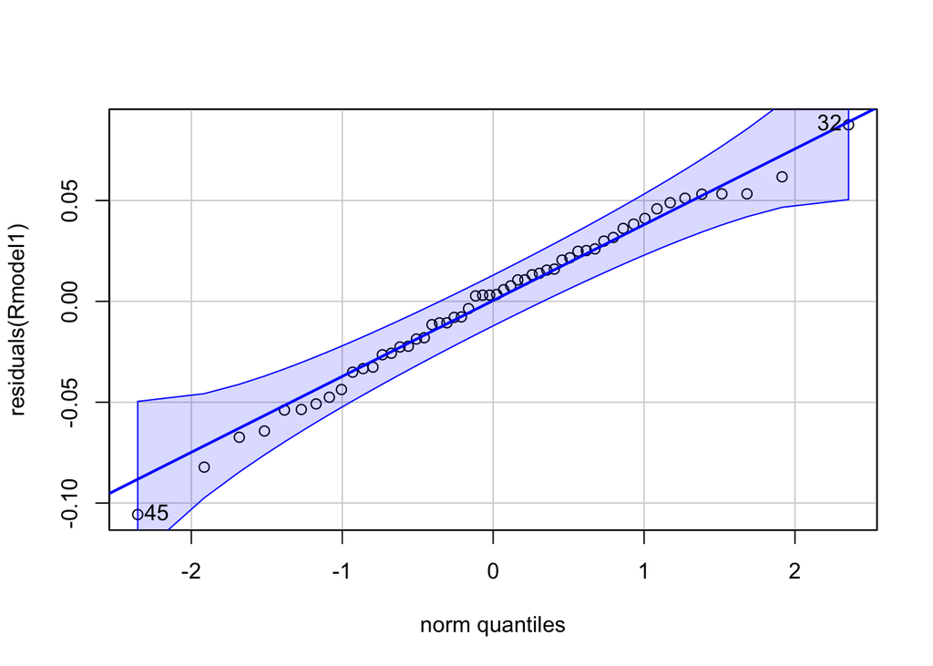

```
## [1] 45 32
```

```r
qqPlot(residuals(Rmodel1))
```

```r
leveneTest(residuals(Rmodel1)~Temperature*Treatment*Stage, data=model_data)
```

```
## Levene's Test for Homogeneity of Variance (center = median)
##       Df F value Pr(>F)
## group  7  1.4835 0.1969
##       46
```

Passes assumptions.

## Net Photosynthesis

Build model and examine for net photosynthesis.

```r
Pmodel1<-aov(P.nmol.org.min~Temperature*Treatment*Stage, data=model_data)
summary(Pmodel1)
```

```
##                             Df  Sum Sq  Mean Sq F value  Pr(>F)
## Temperature                  1 0.01005 0.010055   7.592 0.00837 **
## Treatment                    1 0.00360 0.003598   2.717 0.10611
## Stage                        1 0.01695 0.016952  12.801 0.00083 ***
## Temperature:Treatment        1 0.00373 0.003733   2.819 0.09996 .
## Temperature:Stage            1 0.00352 0.003517   2.656 0.11000
## Treatment:Stage              1 0.00478 0.004784   3.613 0.06362 .
## Temperature:Treatment:Stage  1 0.00117 0.001171   0.884 0.35204
## Residuals                   46 0.06092 0.001324
## ---
## Signif. codes:  0 '***' 0.001 '**' 0.01 '*' 0.05 '.' 0.1 ' ' 1
```

Temperature and stage are significant for net photosynthesis.

Check assumptions of model for residual normality and variance.

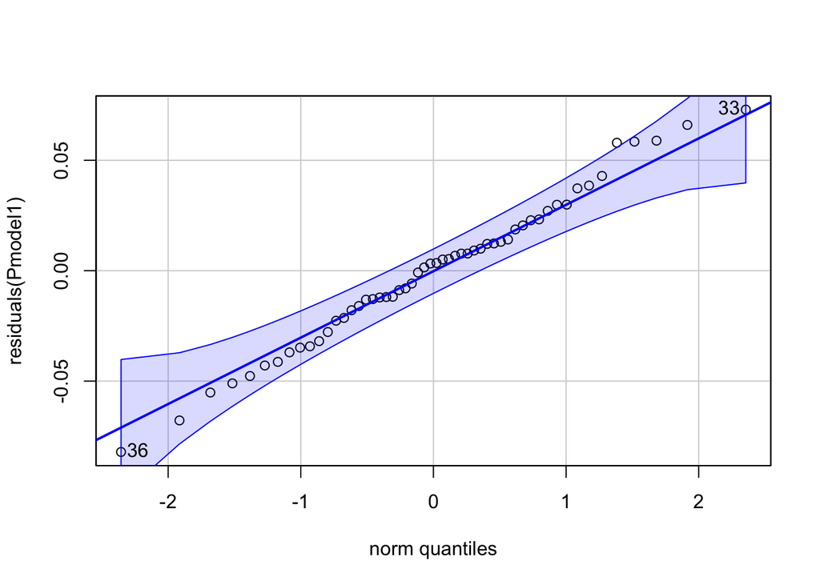

```
## [1] 36 33
```

```r
qqPlot(residuals(Pmodel1))
```

```r
leveneTest(residuals(Pmodel1)~Temperature*Treatment*Stage, data=model_data)
```

```
## Levene's Test for Homogeneity of Variance (center = median)
##       Df F value Pr(>F)
## group  7  0.8267 0.5705
##       46
```

Passes assumptions.

Conduct post hoc test to look at pairwise differences for temperature and treatments between stages.

```r
emm<-emmeans(Pmodel1, ~Temperature*Treatment | Stage)
pairs(emm)
```

```
## Stage = Stage1:
##  contrast                estimate     SE df t.ratio p.value
##  27 Ambient - 31 Ambient -0.05124 0.0210 46  -2.439  0.0839
##  27 Ambient - 27 High    -0.04624 0.0192 46  -2.411  0.0891
##  27 Ambient - 31 High    -0.07812 0.0188 46  -4.157  0.0008
##  31 Ambient - 27 High     0.00499 0.0192 46   0.260  0.9937
##  31 Ambient - 31 High    -0.02688 0.0188 46  -1.430  0.4874
##  27 High - 31 High       -0.03187 0.0167 46  -1.906  0.2397
##
## Stage = Stage2:
##  contrast                estimate     SE df t.ratio p.value
##  27 Ambient - 31 Ambient -0.03937 0.0220 46  -1.787  0.2927
##  27 Ambient - 27 High    -0.02745 0.0220 46  -1.246  0.6014
##  27 Ambient - 31 High    -0.00929 0.0220 46  -0.422  0.9745
##  31 Ambient - 27 High     0.01192 0.0210 46   0.567  0.9413
##  31 Ambient - 31 High     0.03008 0.0210 46   1.432  0.4865
##  27 High - 31 High        0.01816 0.0210 46   0.864  0.8231
##
## P value adjustment: tukey method for comparing a family of 4 estimates
```

Next, conduct post hoc test to look at pairwise differences for stages and treatments between temperatures

```r
emm<-emmeans(Pmodel1, ~Stage*Treatment | Temperature)
pairs(emm)
```

```
## Temperature = 27:
##  contrast                        estimate     SE df t.ratio p.value
##  Stage1 Ambient - Stage2 Ambient -0.06302 0.0220 46  -2.860  0.0312
##  Stage1 Ambient - Stage1 High    -0.04624 0.0192 46  -2.411  0.0891
##  Stage1 Ambient - Stage2 High    -0.09047 0.0210 46  -4.306  0.0005
##  Stage2 Ambient - Stage1 High     0.01677 0.0203 46   0.826  0.8418
##  Stage2 Ambient - Stage2 High    -0.02745 0.0220 46  -1.246  0.6014
##  Stage1 High - Stage2 High       -0.04422 0.0192 46  -2.306  0.1115
##
## Temperature = 31:
##  contrast                        estimate     SE df t.ratio p.value
##  Stage1 Ambient - Stage2 Ambient -0.05115 0.0210 46  -2.435  0.0847
##  Stage1 Ambient - Stage1 High    -0.02688 0.0188 46  -1.430  0.4874
##  Stage1 Ambient - Stage2 High    -0.02107 0.0210 46  -1.003  0.7485
##  Stage2 Ambient - Stage1 High     0.02427 0.0188 46   1.292  0.5728
##  Stage2 Ambient - Stage2 High     0.03008 0.0210 46   1.432  0.4865
##  Stage1 High - Stage2 High        0.00581 0.0188 46   0.309  0.9896
##
## P value adjustment: tukey method for comparing a family of 4 estimates
```

## Gross Photosynthesis

```r
GPmodel1<-aov(GP.nmol.org.min~Temperature*Treatment*Stage, data=model_data)
summary(GPmodel1)
```

```
##                             Df  Sum Sq Mean Sq F value  Pr(>F)
## Temperature                  1 0.00549 0.00549   1.618 0.20983
## Treatment                    1 0.00887 0.00887   2.615 0.11268
## Stage                        1 0.04082 0.04082  12.033 0.00115 **
## Temperature:Treatment        1 0.02964 0.02964   8.737 0.00490 **
## Temperature:Stage            1 0.00607 0.00607   1.790 0.18749
## Treatment:Stage              1 0.00643 0.00643   1.896 0.17516
## Temperature:Treatment:Stage  1 0.00851 0.00851   2.510 0.11999
## Residuals                   46 0.15605 0.00339
## ---
## Signif. codes:  0 '***' 0.001 '**' 0.01 '*' 0.05 '.' 0.1 ' ' 1
```

Stage and Temperature x treatment interaction are significant.

Check assumptions of model for residual normality and variance.

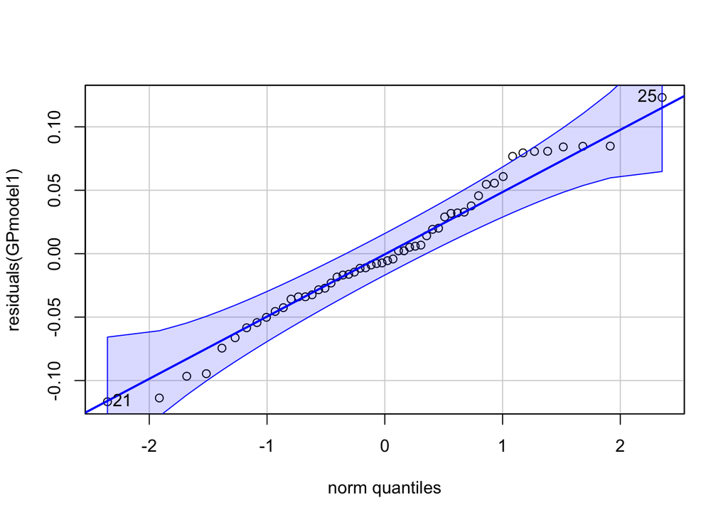

```
## [1] 25 21
```

```r
qqPlot(residuals(GPmodel1))
```

```r
leveneTest(residuals(GPmodel1)~Temperature*Treatment*Stage, data=model_data)
```

```
## Levene's Test for Homogeneity of Variance (center = median)
##       Df F value Pr(>F)
## group  7   0.754 0.6281
##       46
```

Passes.

Conduct post hoc test looking between stages.

```r
emm<-emmeans(GPmodel1, ~Temperature*Treatment | Stage)
pairs(emm)
```

```
## Stage = Stage1:
##  contrast                estimate     SE df t.ratio p.value
##  27 Ambient - 31 Ambient  -0.0667 0.0336 46  -1.982  0.2095
##  27 Ambient - 27 High     -0.0776 0.0307 46  -2.529  0.0685
##  27 Ambient - 31 High     -0.0912 0.0301 46  -3.033  0.0200
##  31 Ambient - 27 High     -0.0110 0.0307 46  -0.358  0.9841
##  31 Ambient - 31 High     -0.0246 0.0301 46  -0.817  0.8462
##  27 High - 31 High        -0.0136 0.0268 46  -0.508  0.9569
##
## Stage = Stage2:
##  contrast                estimate     SE df t.ratio p.value
##  27 Ambient - 31 Ambient  -0.0808 0.0353 46  -2.292  0.1147
##  27 Ambient - 27 High     -0.0862 0.0353 46  -2.445  0.0827
##  27 Ambient - 31 High     -0.0111 0.0353 46  -0.314  0.9891
##  31 Ambient - 27 High     -0.0054 0.0336 46  -0.161  0.9985
##  31 Ambient - 31 High      0.0698 0.0336 46   2.075  0.1766
##  27 High - 31 High         0.0752 0.0336 46   2.235  0.1289
##
## P value adjustment: tukey method for comparing a family of 4 estimates
```

Conduct post hoc test looking between temperatures

```r
emm<-emmeans(GPmodel1, ~Stage*Treatment | Temperature)
pairs(emm)
```

```
## Temperature = 27:
##  contrast                        estimate     SE df t.ratio p.value
##  Stage1 Ambient - Stage2 Ambient -0.07152 0.0353 46  -2.028  0.1928
##  Stage1 Ambient - Stage1 High    -0.07765 0.0307 46  -2.529  0.0685
##  Stage1 Ambient - Stage2 High    -0.15776 0.0336 46  -4.692  0.0001
##  Stage2 Ambient - Stage1 High    -0.00613 0.0325 46  -0.189  0.9976
##  Stage2 Ambient - Stage2 High    -0.08625 0.0353 46  -2.445  0.0827
##  Stage1 High - Stage2 High       -0.08012 0.0307 46  -2.610  0.0570
##
## Temperature = 31:
##  contrast                        estimate     SE df t.ratio p.value
##  Stage1 Ambient - Stage2 Ambient -0.08570 0.0336 46  -2.549  0.0656
##  Stage1 Ambient - Stage1 High    -0.02457 0.0301 46  -0.817  0.8462
##  Stage1 Ambient - Stage2 High    -0.01593 0.0336 46  -0.474  0.9645
##  Stage2 Ambient - Stage1 High     0.06113 0.0301 46   2.032  0.1912
##  Stage2 Ambient - Stage2 High     0.06977 0.0336 46   2.075  0.1766
##  Stage1 High - Stage2 High        0.00864 0.0301 46   0.287  0.9916
##
## P value adjustment: tukey method for comparing a family of 4 estimates
```

## P:R ratio

Build model and examine for PR ratio.

```r
PRmodel1<-aov(ratio~Temperature*Treatment*Stage, data=model_data)
summary(PRmodel1)
```

```
##                             Df Sum Sq Mean Sq F value Pr(>F)
## Temperature                  1   0.79   0.785   0.119  0.731
## Treatment                    1   0.64   0.639   0.097  0.757
## Stage                        1  12.05  12.055   1.833  0.182
## Temperature:Treatment        1   7.30   7.303   1.111  0.297
## Temperature:Stage            1  13.31  13.308   2.024  0.162
## Treatment:Stage              1   2.51   2.509   0.382  0.540
## Temperature:Treatment:Stage  1   1.17   1.172   0.178  0.675
## Residuals                   46 302.50   6.576
```

No significant effects for P:R ratio.

Check assumptions of model for residual normality and variance.

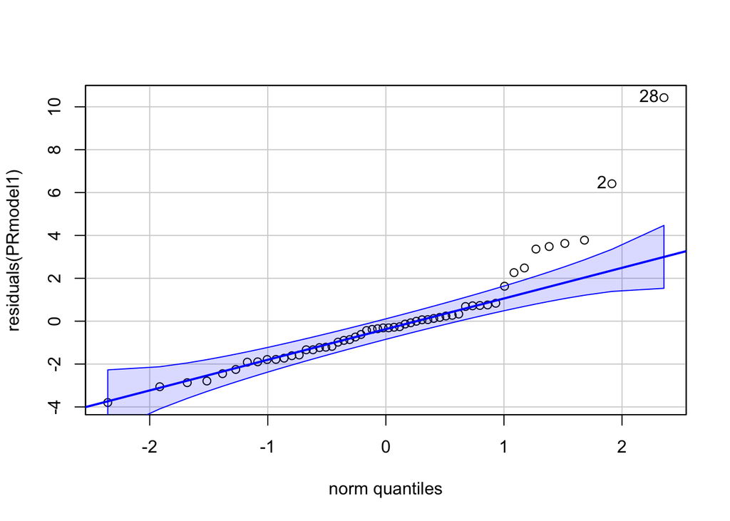

```
## [1] 28  2
```

```r
qqPlot(residuals(PRmodel1))
```

```r
leveneTest(residuals(PRmodel1)~Temperature*Treatment*Stage, data=model_data)
```

```
## Levene's Test for Homogeneity of Variance (center = median)
##       Df F value Pr(>F)
## group  7  1.4654 0.2034
##       46
```

Conduct post hoc test within stage.

```r
emm<-emmeans(PRmodel1, ~Temperature*Treatment | Stage)
pairs(emm)
```

```
## Stage = Stage1:
##  contrast                estimate   SE df t.ratio p.value
##  27 Ambient - 31 Ambient    2.359 1.48 46   1.594  0.3923
##  27 Ambient - 27 High       1.346 1.35 46   0.996  0.7526
##  27 Ambient - 31 High       1.520 1.32 46   1.148  0.6622
##  31 Ambient - 27 High      -1.014 1.35 46  -0.750  0.8762
##  31 Ambient - 31 High      -0.839 1.32 46  -0.634  0.9206
##  27 High - 31 High          0.174 1.18 46   0.148  0.9988
##
## Stage = Stage2:
##  contrast                estimate   SE df t.ratio p.value
##  27 Ambient - 31 Ambient   -0.350 1.55 46  -0.226  0.9959
##  27 Ambient - 27 High      -0.163 1.55 46  -0.105  0.9996
##  27 Ambient - 31 High      -1.490 1.55 46  -0.960  0.7727
##  31 Ambient - 27 High       0.188 1.48 46   0.127  0.9993
##  31 Ambient - 31 High      -1.140 1.48 46  -0.770  0.8676
##  27 High - 31 High         -1.328 1.48 46  -0.897  0.8066
##
## P value adjustment: tukey method for comparing a family of 4 estimates
```

Conduct post hoc test within temperature

```r
emm<-emmeans(PRmodel1, ~Stage*Treatment | Temperature)
pairs(emm)
```

```
## Temperature = 27:
##  contrast                        estimate   SE df t.ratio p.value
##  Stage1 Ambient - Stage2 Ambient    2.833 1.55 46   1.825  0.2751
##  Stage1 Ambient - Stage1 High       1.346 1.35 46   0.996  0.7526
##  Stage1 Ambient - Stage2 High       2.670 1.48 46   1.804  0.2847
##  Stage2 Ambient - Stage1 High      -1.488 1.43 46  -1.040  0.7270
##  Stage2 Ambient - Stage2 High      -0.163 1.55 46  -0.105  0.9996
##  Stage1 High - Stage2 High          1.325 1.35 46   0.980  0.7613
##
## Temperature = 31:
##  contrast                        estimate   SE df t.ratio p.value
##  Stage1 Ambient - Stage2 Ambient    0.123 1.48 46   0.083  0.9998
##  Stage1 Ambient - Stage1 High      -0.839 1.32 46  -0.634  0.9206
##  Stage1 Ambient - Stage2 High      -1.017 1.48 46  -0.687  0.9017
##  Stage2 Ambient - Stage1 High      -0.963 1.32 46  -0.727  0.8858
##  Stage2 Ambient - Stage2 High      -1.140 1.48 46  -0.770  0.8676
##  Stage1 High - Stage2 High         -0.177 1.32 46  -0.134  0.9991
##
## P value adjustment: tukey method for comparing a family of 4 estimates
```

## Generate summary table

Generate summary of all respiration data.

```r
summary<-PRdata%>%
  group_by(Temperature, Treatment, Stage)%>%
  summarise(N=length(R.nmol.org.min),
            Mean_R=mean(R.nmol.org.min),
            SE_R=sd(R.nmol.org.min)/sqrt(length(R.nmol.org.min)),
            Mean_P=mean(P.nmol.org.min),
            SE_P=sd(P.nmol.org.min)/sqrt(length(P.nmol.org.min)),
            Mean_GP=mean(GP.nmol.org.min),
            SE_GP=sd(GP.nmol.org.min)/sqrt(length(GP.nmol.org.min)),
            Mean_PR=mean(ratio),
            SE_PR=sd(ratio)/sqrt(length(ratio)));summary
```

```
## # A tibble: 10 × 12
## # Groups:   Temperature, Treatment [4]
##    Temperature Treatment Stage      N  Mean_R    SE_R    Mean_P    SE_P Mean_GP
##    <fct>       <fct>     <fct>  <int>   <dbl>   <dbl>     <dbl>   <dbl>   <dbl>
##  1 27          Ambient   Stage1     6 -0.0249 0.0197  -0.0411   0.0137  -0.0162
##  2 27          Ambient   Stage2     5 -0.0334 0.0132   0.0219   0.00680  0.0553
##  3 27          Ambient   Stage3     6 -0.0228 0.0138   0.00404  0.0189   0.0268
##  4 27          High      Stage1     9 -0.0563 0.0200   0.00515  0.0161   0.0614
##  5 27          High      Stage2     6 -0.0922 0.00708  0.0494   0.0169   0.142
##  6 31          Ambient   Stage1     6 -0.0403 0.0157   0.0101   0.0102   0.0504
##  7 31          Ambient   Stage2     6 -0.0748 0.0131   0.0613   0.0155   0.136
##  8 31          Ambient   Stage3     6 -0.0597 0.00649 -0.000809 0.0116   0.0589
##  9 31          High      Stage1    10 -0.0380 0.0152   0.0370   0.0127   0.0750
## 10 31          High      Stage2     6 -0.0352 0.0125   0.0312   0.00871  0.0664
## # … with 3 more variables: SE_GP <dbl>, Mean_PR <dbl>, SE_PR <dbl>
```

```r
summary%>%
  write_csv(., "Pacu2021/Output/Respiration/Stages/mean_respiration.csv")
```